# Appendix B: Demonstration with Simulated Data

Tan, L. Y.

2026-08-21

## Overview

Granted that there are likely many different scenarios that might not fit into the simulation here, but the goal is to demonstate the effects of repeat test-takers on item estimates.

## 1. DF: Simulated Dataframe with Known Parameters

This data frame has all “test-takers” responding to all “items”, and the item estimates shall be the true parameters.

```r
set.seed(101)

# 1. Define sample size
N <- 4000   # number of persons
J <- 2000    # number of items

# 2. Generate known parameters
theta <- rnorm(N, mean = 0, sd = 1)     # person ability
b     <- rnorm(J, mean = 0, sd = 1)     # item difficulty

# 3. Compute response probabilities (1-IRT model)
#    P(X_ij = 1) = exp(theta_i - b_j) / (1 + exp(theta_i - b_j))
prob_matrix <- outer(theta, b, function(th, bj) {
  exp(th - bj) / (1 + exp(th - bj))
})

# 4. Generate binary responses
response_matrix <- matrix(
  rbinom(N * J, size = 1, prob = as.vector(prob_matrix)),
  nrow = N,
  ncol = J
)

# 5. Assign row/column names
colnames(response_matrix) <- paste0("Item", 1:J)
rownames(response_matrix) <- paste0("Person", 1:N)

# 6. Save and export DF
DF <- response_matrix
write.csv(DF, "df.csv", row.names = TRUE)
```

### 1.1 “True” Estimates using JLME

The “true” item estimates are derived using JLME as a point of reference. The reason for choosing JLME as the estimation method is because bigIRT package uses JLME on its first pass to compute Bayesian priors.

#### 1.1.1 Summary Statistics for DF using JLME (WinSteps)

```
     SUMMARY OF 2000 MEASURED ITEM
-------------------------------------------------------------------------------
|          TOTAL                         MODEL         INFIT        OUTFIT    |
|          SCORE     COUNT     MEASURE    S.E.      MNSQ   ZSTD   MNSQ   ZSTD |
|-----------------------------------------------------------------------------|
| MEAN    1995.9    4000.0         .00     .04      1.00   -.05   1.00   -.06 |
|  SEM      16.4        .0         .02     .00       .00    .02    .00    .02 |
| P.SD     733.7        .0        1.01     .00       .01    .84    .03    .91 |
| S.SD     733.9        .0        1.01     .00       .01    .84    .03    .91 |
| MAX.    3805.0    4000.0        3.34     .08      1.04   2.99   1.12   2.60 |
| MIN.     203.0    4000.0       -3.39     .03       .96  -3.13    .87  -3.56 |
|-----------------------------------------------------------------------------|
| REAL RMSE    .04 TRUE SD    1.00  SEPARATION 26.43  ITEM   RELIABILITY 1.00 |
|MODEL RMSE    .04 TRUE SD    1.00  SEPARATION 26.49  ITEM   RELIABILITY 1.00 |
| S.E. OF ITEM MEAN = .02                                                     |
-------------------------------------------------------------------------------
ITEM RAW SCORE-TO-MEASURE CORRELATION = -1.00
Global statistics: please see Table 44.
UMEAN=.0000 USCALE=1.0000
```

#### 1.1.2 “True” Item Estimates for DF

The following truncated table displays the “true” item difficulty measures:

```r
TABLE 10.1 df.csv                                ZOU000WS.TXT  Aug 21 2026 10:26
INPUT: 4000 PERSON  2000 ITEM  REPORTED: 4000 PERSON  2000 ITEM  2 CATS WINSTEPS 5.10.0.0
-----------------------------------------------------------------------------------------
PERSON: REAL SEP.: 18.49  REL.: 1.00 ... ITEM: REAL SEP.: 26.43  REL.: 1.00

         ITEM STATISTICS:  MISFIT ORDER

----------------------------------------------------------------------------------------------
|ENTRY   TOTAL  TOTAL    JMLE   MODEL|   INFIT  |  OUTFIT  |PTMEASUR-AL|EXACT MATCH|         |
|NUMBER  SCORE  COUNT  MEASURE  S.E. |MNSQ  ZSTD|MNSQ  ZSTD|CORR.  EXP.| OBS%  EXP%| ITEM    |
|------------------------------------+----------+----------+-----------+-----------+---------|
|  1873   3782   4000   -3.27     .07|1.01   .23|1.12  1.15|A .19   .21| 94.6  94.5| Item1873|
|   444   3727   4000   -3.01     .06|1.00  -.06|1.11  1.24|B .23   .23| 93.2  93.2| Item444 |
|  1619    948   4000    1.39     .04|1.03  1.49|1.09  2.50|C .33   .36| 77.5  78.0| Item1619|
|  1670   3595   4000   -2.55     .05|1.04   .95|1.09  1.32|D .23   .27| 89.8  89.9| Item1670|
|   271   3275   4000   -1.79     .04|1.01   .37|1.08  1.71|E .32   .33| 82.4  82.5| Item271 |
|  1063    675   4000    1.88     .05|1.03   .96|1.08  1.73|F .30   .33| 83.4  83.6| Item1063|
|  1161   3112   4000   -1.50     .04|1.03  1.52|1.08  1.96|G .32   .36| 78.3  79.1| Item1161|
|  1510   3244   4000   -1.73     .04|1.01   .29|1.08  1.72|H .32   .34| 82.3  81.9| Item1510|
|  1655    916   4000    1.44     .04|1.01   .37|1.08  2.04|I .34   .36| 78.7  78.6| Item1655|
|  1738    511   4000    2.25     .05|1.01   .18|1.08  1.31|J .28   .30| 87.4  87.4| Item1738|
|    75    509   4000    2.25     .05|1.02   .62|1.07  1.21|K .27   .30| 87.3  87.4| Item75  |
|   111   3378   4000   -2.00     .05|1.00   .09|1.07  1.30|L .31   .32| 84.9  84.8| Item111 |
|   559    986   4000    1.33     .04|1.03  1.25|1.07  1.98|M .34   .37| 76.9  77.3| Item559 |
|  1305   2909   4000   -1.18     .04|1.04  1.97|1.07  2.27|N .34   .38| 74.8  75.4| Item1305|
|  1723   3304   4000   -1.84     .04|1.02   .61|1.07  1.47|O .31   .33| 83.0  83.1| Item1723|
|  1991   3399   4000   -2.04     .05| .99  -.28|1.07  1.31|P .31   .31| 85.5  85.3| Item1991|
|   136    746   4000    1.74     .04|1.01   .60|1.06  1.43|Q .32   .34| 81.8  82.0| Item136 |
|   203   3570   4000   -2.47     .05|1.02   .45|1.06   .90|R .26   .28| 89.4  89.3| Item203 |
|   219   3413   4000   -2.07     .05|1.01   .24|1.06  1.18|S .30   .31| 85.7  85.6| Item219 |
|   226   3708   4000   -2.94     .06|1.00   .10|1.06   .74|T .23   .24| 92.8  92.7| Item226 |
|   505    639   4000    1.96     .05|1.01   .42|1.06  1.27|U .30   .32| 84.6  84.4| Item505 |
|   633    759   4000    1.72     .04|1.03  1.13|1.06  1.40|V .31   .34| 81.9  81.8| Item633 |
|  1037   3622   4000   -2.63     .06|1.00   .12|1.06   .78|W .26   .26| 90.5  90.6| Item1037|
|  1214    979   4000    1.34     .04|1.03  1.32|1.06  1.68|X .34   .37| 77.3  77.4| Item1214|
|  1588    634   4000    1.97     .05|1.01   .20|1.06  1.18|Y .31   .32| 84.5  84.5| Item1588|
|  1783   1206   4000    1.00     .04|1.02  1.41|1.06  2.04|Z .36   .39| 73.7  73.6| Item1783|
|  1817   2771   4000    -.98     .04|1.02  1.42|1.06  2.26|  .36   .39| 72.7  73.2| Item1817|
|  1865   1377   4000     .77     .04|1.03  2.16|1.06  2.30|  .36   .40| 69.9  71.3| Item1865|
|    93   1416   4000     .72     .04|1.03  2.07|1.05  2.01|  .37   .40| 69.2  70.9| Item93  |
|   209   2572   4000    -.71     .04|1.02  1.44|1.05  2.14|  .38   .40| 70.5  70.6| Item209 |
|   458   1402   4000     .74     .04|1.01   .83|1.05  2.12|  .38   .40| 70.5  71.0| Item458 |
|   607   1437   4000     .69     .04|1.03  2.13|1.05  1.99|  .37   .40| 69.7  70.7| Item607 |
|   942   2222   4000    -.27     .03|1.02  1.57|1.05  2.60|  .39   .41| 66.6  67.9| Item942 |
|  1183   2401   4000    -.49     .04|1.04  2.99|1.05  2.32|  .37   .41| 67.3  69.0| Item1183|
|  1217   1462   4000     .66     .04|1.03  2.26|1.05  2.05|  .37   .40| 69.6  70.4| Item1217|
|  1483   2246   4000    -.30     .03|1.02  1.77|1.05  2.41|  .38   .41| 67.2  68.0| Item1483|
|  1648   1365   4000     .79     .04|1.01   .84|1.05  2.07|  .38   .40| 71.5  71.5| Item1648|
|  1711   2177   4000    -.22     .03|1.03  2.11|1.05  2.53|  .38   .41| 66.6  67.7| Item1711|
|    38   1895   4000     .12     .03|1.02  1.92|1.04  2.37|  .39   .41| 66.6  67.6| Item38  |
|    57   1474   4000     .64     .04|1.03  2.02|1.04  1.98|  .37   .40| 69.2  70.3| Item57  |
|    80   2431   4000    -.53     .04|1.03  1.95|1.04  2.10|  .38   .40| 67.8  69.2| Item80  |
|   127   2329   4000    -.40     .04|1.03  2.34|1.04  2.20|  .38   .41| 66.9  68.5| Item127 |
|   180   2144   4000    -.18     .03|1.03  2.05|1.04  2.19|  .39   .41| 66.8  67.6| Item180 |
|   387   2076   4000    -.10     .03|1.02  1.37|1.04  2.23|  .39   .41| 67.0  67.5| Item387 |
|   462   1904   4000     .11     .03|1.03  2.40|1.04  2.33|  .38   .41| 66.8  67.6| Item462 |
|   527   2019   4000    -.03     .03|1.02  1.78|1.04  2.28|  .39   .41| 66.7  67.4| Item527 |
|   564   1530   4000     .57     .04|1.03  2.01|1.04  2.04|  .38   .40| 68.3  69.7| Item564 |
|   769   2548   4000    -.68     .04|1.03  2.01|1.04  1.82|  .37   .40| 69.4  70.4| Item769 |
|   809   2303   4000    -.37     .04|1.02  1.49|1.04  2.01|  .39   .41| 67.7  68.3| Item809 |
|   915   2291   4000    -.36     .04|1.03  2.59|1.04  2.11|  .38   .41| 67.1  68.2| Item915 |
|  1274   1797   4000     .24     .03|1.03  2.35|1.04  2.07|  .38   .41| 65.7  67.9| Item1274|
|  1333   1696   4000     .37     .04|1.04  2.66|1.04  1.86|  .38   .41| 65.8  68.4| Item1333|
|  1372   1709   4000     .35     .04|1.03  1.92|1.04  2.14|  .38   .41| 67.3  68.3| Item1372|
|  1565   1837   4000     .19     .03|1.03  2.13|1.04  2.04|  .39   .41| 66.7  67.7| Item1565|
|  1759   2073   4000    -.09     .03|1.02  1.71|1.04  2.04|  .39   .41| 66.3  67.5| Item1759|
|  1928   1867   4000     .16     .03|1.01   .85|1.04  2.01|  .40   .41| 67.3  67.6| Item1928|
|  1980   1825   4000     .21     .03|1.03  2.30|1.04  2.22|  .38   .41| 66.4  67.8| Item1980|
|   578   2044   4000    -.06     .03|1.03  2.07|1.03  1.83|  .39   .41| 65.3  67.4| Item578 |
|   931   1646   4000     .43     .04|1.03  2.05|1.03  1.57|  .38   .41| 67.8  68.7| Item931 |
|   960   2244   4000    -.30     .03|1.03  2.01|1.03  1.61|  .39   .41| 66.1  68.0| Item960 |
|  1143   2036   4000    -.05     .03|1.03  2.08|1.02  1.35|  .39   .41| 66.2  67.4| Item1143|
|  1515   1934   4000     .08     .03|1.03  2.11|1.03  1.90|  .39   .41| 66.4  67.5| Item1515|
|  1770   2291   4000    -.36     .04|1.03  2.35|1.03  1.35|  .38   .41| 66.3  68.2| Item1770|
|       BETTER FITTING NOT SHOWN     +----------+----------+           |           |         |
|  1463   2225   4000    -.28     .03| .99 -1.14| .96 -2.11|  .43   .41| 67.6  67.9| Item1463|
|    96    938   4000    1.41     .04| .98  -.98| .92 -2.23|  .39   .36| 78.4  78.2| Item96  |
|   965   2392   4000    -.48     .04| .98 -1.66| .95 -2.29|  .43   .41| 70.0  68.9| Item965 |
|   990   1880   4000     .14     .03| .98 -1.95| .96 -2.25|  .44   .41| 68.9  67.6| Item990 |
|  1341    803   4000    1.64     .04| .98  -.93| .91 -2.31|  .37   .35| 80.9  80.8| Item1341|
|  1558   2575   4000    -.72     .04| .98 -1.68| .94 -2.61|  .43   .40| 70.8  70.7| Item1558|
|  1761   1913   4000     .10     .03| .98 -1.84| .96 -2.23|  .44   .41| 68.5  67.5| Item1761|
|    10   2150   4000    -.19     .03| .97 -2.53| .96 -2.16|  .44   .41| 69.6  67.6| Item10  |
|    73   2425   4000    -.52     .04| .97 -2.39| .97 -1.42|  .43   .40| 71.4  69.2| Item73  |
|   120   2291   4000    -.36     .04| .97 -2.40| .95 -2.39|  .44   .41| 69.1  68.2| Item120 |
|   236   2166   4000    -.20     .03| .97 -2.19| .96 -1.96|  .44   .41| 68.5  67.6| Item236 |
|   378   2413   4000    -.51     .04| .97 -2.23| .97 -1.40|  .43   .41| 71.1  69.1| Item378 |
|   435   2078   4000    -.10     .03| .97 -2.53| .96 -2.43|  .44   .41| 68.3  67.5| Item435 |
|   539   2170   4000    -.21     .03| .97 -2.26| .96 -2.01|  .44   .41| 69.1  67.7| Item539 |
|   833   2109   4000    -.14     .03| .97 -2.33| .97 -1.91|  .44   .41| 69.3  67.5| Item833 |
|   905   2128   4000    -.16     .03| .97 -2.14| .97 -1.73|  .44   .41| 68.9  67.6| Item905 |
|   913   1403   4000     .74     .04| .97 -2.01| .96 -1.57|z .43   .40| 72.3  71.0| Item913 |
|   993   3068   4000   -1.42     .04| .97 -1.55| .94 -1.80|y .39   .36| 78.9  78.3| Item993 |
|  1082   2901   4000   -1.16     .04| .97 -1.65| .95 -1.72|x .41   .38| 76.2  75.3| Item1082|
|  1118   2197   4000    -.24     .03| .97 -2.56| .95 -2.59|w .44   .41| 69.1  67.8| Item1118|
|  1194    883   4000    1.50     .04| .97 -1.22| .95 -1.26|v .38   .36| 80.2  79.2| Item1194|
|  1227   1646   4000     .43     .04| .97 -2.24| .96 -2.06|u .44   .41| 69.8  68.7| Item1227|
|  1352   2268   4000    -.33     .04| .97 -2.01| .97 -1.84|t .43   .41| 68.7  68.1| Item1352|
|  1368   1444   4000     .68     .04| .97 -2.35| .95 -2.24|s .43   .40| 72.0  70.6| Item1368|
|  1410    562   4000    2.13     .05| .97  -.95| .93 -1.24|r .33   .31| 86.6  86.2| Item1410|
|  1500   1401   4000     .74     .04| .97 -1.85| .96 -1.58|q .42   .40| 72.4  71.1| Item1500|
|  1517   3112   4000   -1.50     .04| .97 -1.51| .92 -2.06|p .39   .36| 80.0  79.1| Item1517|
|  1530   1257   4000     .93     .04| .97 -1.67| .96 -1.52|o .42   .39| 73.9  72.9| Item1530|
|  1547   3308   4000   -1.85     .04| .97  -.97| .95 -1.01|n .35   .33| 83.7  83.2| Item1547|
|  1550   1276   4000     .91     .04| .97 -1.55| .97 -1.01|m .41   .39| 74.2  72.7| Item1550|
|  1577   1549   4000     .55     .04| .97 -2.04| .96 -1.75|l .43   .40| 70.7  69.5| Item1577|
|  1777   2801   4000   -1.02     .04| .97 -1.62| .94 -2.02|k .41   .38| 74.6  73.7| Item1777|
|  1782   1625   4000     .45     .04| .97 -1.86| .96 -1.90|j .43   .41| 69.9  68.9| Item1782|
|  1818    847   4000    1.56     .04| .97 -1.51| .92 -2.04|i .39   .35| 80.6  79.9| Item1818|
|  1900   2010   4000    -.02     .03| .97 -2.16| .97 -1.74|h .44   .41| 68.4  67.4| Item1900|
|  1965   2213   4000    -.26     .03| .97 -2.05| .96 -1.91|g .44   .41| 69.1  67.8| Item1965|
|   145   2036   4000    -.05     .03| .96 -3.13| .95 -3.06|f .45   .41| 68.7  67.4| Item145 |
|   159   1494   4000     .62     .04| .96 -2.61| .95 -2.29|e .44   .40| 71.3  70.1| Item159 |
|  1241   1354   4000     .80     .04| .96 -2.42| .95 -2.13|d .43   .40| 73.1  71.6| Item1241|
|  1508   1764   4000     .28     .03| .96 -2.76| .95 -2.71|c .44   .41| 69.6  68.0| Item1508|
|  1544   1082   4000    1.18     .04| .96 -2.01| .96 -1.38|b .41   .38| 76.4  75.6| Item1544|
|  1850   2065   4000    -.08     .03| .96 -2.88| .94 -3.56|a .45   .41| 68.9  67.5| Item1850|
|------------------------------------+----------+----------+-----------+-----------+---------|
| MEAN  1995.9 4000.0     .00     .04|1.00  -.05|1.00  -.06|           | 72.6  72.5|         |
| P.SD   733.7     .0    1.01     .00| .01   .84| .03   .91|           |  5.6   5.6|         |
----------------------------------------------------------------------------------------------
```

## 2. DF_missing: Simulated Sparse Dataframe

Using DF as the basis, all 4000 “test-takers” have missing observations, such that each “person” would have answered only 20 out of the 2000 questions.

```r
set.seed(2026)

DF <- read.csv("df.csv", stringsAsFactors = FALSE)

# Separate ID column so it isn't blanked out
id  <- DF[[1]]
DF  <- DF[, -1]

n_items  <- ncol(DF)                 # 2000
n_remove <- 1980                     # per row
n_rows   <- nrow(DF)

stopifnot(n_items == 2000, n_remove < n_items)

M <- as.matrix(DF)                  # matrix ops need a matrix
storage.mode(M) <- "integer"        # 0/1 stay integer; NA_integer_ is valid

# For each row, draw 400 distinct column indices without replacement
cols <- vapply(seq_len(n_rows),
               function(i) sample.int(n_items, n_remove),
               integer(n_remove))   # result: 400 x n_rows matrix

# Build the (row, col) index pairs
idx <- cbind(rep(seq_len(n_rows), each = n_remove),  # row indices
             as.vector(cols))                        # matching column indices

M[idx] <- NA_integer_

DF_missing <- as.data.frame(M)
DF_missing <- cbind(ID = id, DF_missing)

# 6. Save and export DF_missing
write.csv(DF_missing, "df_missing.csv", row.names = FALSE)
```

### 2.1 Summary Statistics for DF_missing

Total person scores and total item scores were computed, and below is the summary statistics and histogram for the person scores and item scores in DF_missing.

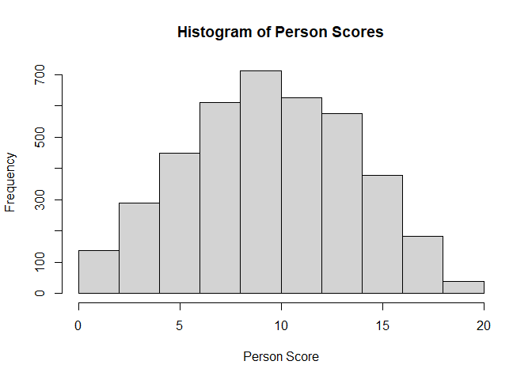

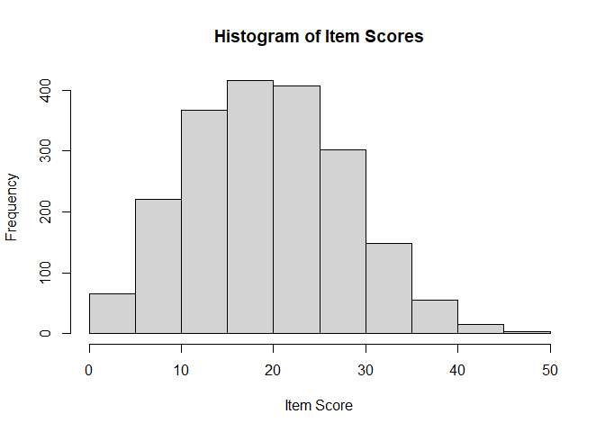

Below is the descriptive statistics describing the distribution of person and item scores in DF_missing:

```
|Summary Stats | Min | 1st Qu.| Median |  Mean   |   SD   | 3rd Qu | Max |
|--------------|-----|--------|--------|---------|--------|--------|-----|
|      Persons |  0  |  7.00  |   10   |   9.95  |  4.121 |   13   |  20 |
|        Items |  0  | 13.75  |   20   |  19.90  |  8.519 |   26   |  49 |
```

### 2.2 1-IRT Modelling Using bigIRT

Below is the summary of code for running 1-IRT modelling using bigIRT with DF_missing:

```r
wide <- fread("df_missing.csv")

#names(wide)[1:5]        # confirm the actual id column name before proceeding
#dim(wide)               # expect N x 2001 (1 id + 2000 items)

id_col    <- "ID"
item_cols <- setdiff(names(wide), id_col)      # everything else is an item

stopifnot(length(item_cols) == 2000)

# force item columns to integer BEFORE melting, so no type-hierarchy coercion occurs
wide[, (item_cols) := lapply(.SD, function(x) as.integer(as.character(x))),
     .SDcols = item_cols]

# integer person index; keep the original label in a lookup table
setnames(wide, id_col, "person_label")
wide[, id := seq_len(.N)]

lookup <- wide[, .(id, person_label)]

long <- melt(wide,
             id.vars       = "id",
             measure.vars  = item_cols,
             variable.name = "Item",
             value.name    = "score",
             na.rm         = TRUE)

long[, Item  := as.character(Item)]            # melt returns a factor
long[, Scale := "scale1"]

#long[, .N, by = id][, summary(N)]     # every value must be exactly 20
#long[, .N, by = score]                # only 0 and 1, no NA row
stopifnot(!anyNA(long$score),
          all(long$score %in% c(0L, 1L)),
          uniqueN(long$Item) == 2000)

fit1pl <- fitIRT(long,
                 pl    = 1,
                 score = 'score',
                 id    = 'id',
                 scale = 'Scale',
                 item  = 'Item',
                 dropPerfectScores = TRUE,
                 cores = 2)
```

```
## Free estimation step...
```

```
## Empirical Bayes step...
```

```r
itempars   <- fit1pl$itemPars
personpars <- fit1pl$personPars
#unique(round(itempars$A, 6))          # single value confirms the 1PL constraint

personpars <- merge(personpars, lookup, by = "id", all.x = TRUE)
```

The following shows the output computed by bigIRT:

```r
str(fit1pl, max.level = 1)      # top-level components
```

```
## List of 8
##  $ optim           :List of 8
##  $ parcov          : NULL
##  $ stanfit         :Formal class 'stanfit' [package "rstan"] with 10 slots
##  $ pars            :List of 36
##  $ dat             :List of 87
##  $ itemPars        :'data.frame':    1997 obs. of  5 variables:
##  $ personPars      :'data.frame':    3981 obs. of  2 variables:
##  $ covariateEffects: list()
```

```r
str(itempars)           # col names and types; params not used in 1-IRT not relevant
```

```
## 'data.frame':    1997 obs. of  5 variables:
##  $ Item: chr  "Item1" "Item10" "Item100" "Item1000" ...
##  $ A   : num  1 1 1 1 1 1 1 1 1 1 ...
##  $ B   : num  -1.555 -0.318 1.082 -0.357 1.995 ...
##  $ C   : num  0 0 0 0 0 0 0 0 0 0 ...
##  $ D   : num  1 1 1 1 1 1 1 1 1 1 ...
```

```r
#names(fit1pl)

itempars <- as.data.table(fit1pl$itemPars)

#dim(itempars)          # 1997 rows; 3 items with all 0 not included
#head(itempars, 10)
```

The following shows the top easiest and hardest items:

```r
setorder(itempars, B)

head(itempars[, .(Item, B)], 10)     # top 10 easiest items
```

```
##         Item         B
##       <char>     <num>
##  1:  Item444 -3.552472
##  2: Item1799 -3.296481
##  3:  Item357 -3.259289
##  4: Item1037 -3.049100
##  5: Item1294 -3.043009
##  6:  Item251 -2.939467
##  7:  Item952 -2.847619
##  8: Item1842 -2.834663
##  9: Item1447 -2.788074
## 10: Item1047 -2.699195
```

```r
tail(itempars[, .(Item, B)], 10)     # top 10 hardest items
```

```
##         Item        B
##       <char>    <num>
##  1:  Item704 2.896461
##  2:   Item91 2.936784
##  3:  Item735 2.944017
##  4:  Item587 3.034435
##  5:   Item20 3.124506
##  6:  Item785 3.148491
##  7: Item1012 3.206584
##  8: Item1637 3.238453
##  9:  Item779 3.468032
## 10:  Item470 3.545125
```

The following are the summary statistics of the item estimates. Note that the numbers will change slightly on every run:

```r
summary(itempars$B)    # summary stats of item estimates
```

```
##      Min.   1st Qu.    Median      Mean   3rd Qu.      Max.
## -3.552472 -0.710482  0.016445  0.008669  0.748859  3.545125
```

```r
sd(itempars$B)         # SD of item estimates
```

```
## [1] 1.079548
```

Scatterplot of item estimates vis-a-vis item scores:

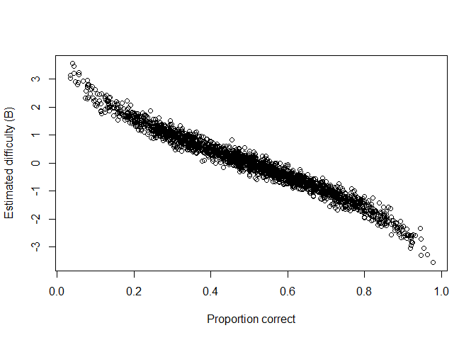

```r
pvals <- long[, .(p_correct = mean(score), n_obs = .N), by = Item]
chk   <- merge(itempars, pvals, by = "Item")

#cor(chk$B, chk$p_correct, method = "spearman")   # expect ≈ -0.95 or lower; r = -0.986176

plot(chk$p_correct, chk$B,
     xlab = "Proportion correct", ylab = "Estimated difficulty (B)")
```

```r
np <- normaliseIRT(B = fit1pl$itemPars$B,
                   A = fit1pl$itemPars$A,
                   Ability = fit1pl$pars$Ability)

itempars_norm <- data.table(Item = fit1pl$itemPars$Item,
                            A = np$A, B = np$B)

fwrite(itempars, "item_estimates_1pl.csv")
```

### 3. DF_repeat: Simulated Dataframe with Repeat Test-Takers

Next, a random 10% of “test-takers” are inserted into DF_missing to create the new dataframe DF_repeat.

```r
set.seed(42)   # reproducibility; remove or change as needed

DF_repeat <- read.csv("df_missing.csv", stringsAsFactors = FALSE)

# Split ID from the response pattern
id_name <- names(DF_repeat)[1]          # preserve the original column name
id      <- DF_repeat[[1]]
resp    <- DF_repeat[, -1, drop = FALSE]

n_persons <- nrow(resp)
n_items   <- ncol(resp)

## Select 10% of persons randomly
n_select <- ceiling(0.10 * n_persons)   # ceiling -> at least 1 when n < 10
stopifnot(n_select >= 1, n_select <= n_persons)

sel_rows <- sample.int(n_persons, n_select, replace = FALSE)

## Draw a copy count in 1...5 times for each selected person
n_copies <- sample(1:5, n_select, replace = TRUE)   # (A) extra copies
# For interpretation (B) instead: n_copies <- sample(0:4, n_select, replace = TRUE)

## Build the row index vector
# Every original row appears once; selected rows appear n_copies extra times
extra_idx <- rep(sel_rows, times = n_copies)
all_idx   <- c(seq_len(n_persons), extra_idx)

## Keep duplicates adjacent to their originals rather than appended
all_idx <- sort(all_idx)

## Materialize the duplicated data
DF_out <- resp[all_idx, , drop = FALSE]
DF_out <- cbind(ID = id[all_idx], DF_out)
names(DF_out)[1] <- id_name
rownames(DF_out) <- NULL

## Check if the code worked
stopifnot(
  nrow(DF_out) == n_persons + sum(n_copies),
  ncol(DF_out) == n_items + 1,
  all(table(DF_out[[1]])[as.character(id[sel_rows])] >= 2)
)

## Export DF_repeat
write.csv(DF_out, "df_repeat.csv", row.names = FALSE)

cat("Persons selected:", n_select,
    "| extra rows added:", sum(n_copies),
    "| final rows:", nrow(DF_out), "\n")
```

```
## Persons selected: 400 | extra rows added: 1153 | final rows: 5153
```

### 3.1 Summary Statistics for DF_repeat

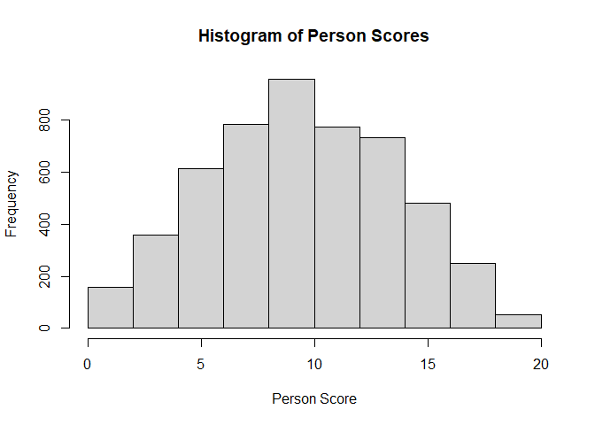

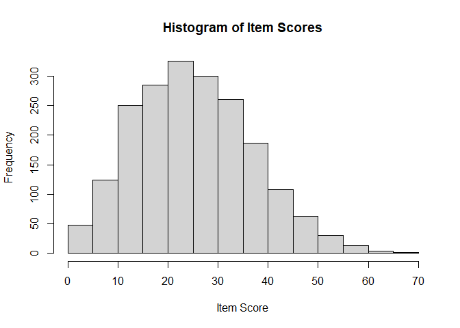

Below is the descriptive statistics describing the distribution of person and item scores in DF_repeat:

```
|Summary Stats | Min | 1st Qu.| Median |  Mean   |   SD   | 3rd Qu | Max |
|--------------|-----|--------|--------|---------|--------|--------|-----|
|      Persons |  0  |  7.00  |   10   |   9.97  |  4.105 |   13   |  20 |
|        Items |  0  |  17.00 |   25   |  25.69  | 11.702 |   34   |  66 |
```

## 3.2. 1-IRT Modelling Using bigIRT

The same steps are applied to DF_repeat using bigIRT:

```r
wide_r <- fread("df_repeat.csv")

#names(wide_r)[1:5]        # confirm the actual id column name before proceeding
#dim(wide_r)               # expect N x 2001 (1 id + 2000 items)

id_col_r    <- "ID"
item_cols_r <- setdiff(names(wide_r), id_col_r) 　 # everything else is an item

stopifnot(length(item_cols_r) == 2000)

# force item columns to integer BEFORE melting, so no type-hierarchy coercion occurs
wide_r[, (item_cols_r) := lapply(.SD, function(x) as.integer(as.character(x))),
     .SDcols = item_cols_r]

# integer person index; keep the original label in a lookup table
setnames(wide_r, id_col_r, "person_label")
wide_r[, id := seq_len(.N)]

lookup_r <- wide_r[, .(id, person_label)]

long_r <- melt(wide_r,
             id.vars       = "id",
             measure.vars  = item_cols_r,
             variable.name = "Item",
             value.name    = "score",
             na.rm         = TRUE)

long_r[, Item  := as.character(Item)]            # melt returns a factor
long_r[, Scale := "scale1"]

#long_r[, .N, by = id][, summary(N)]     # every value must be exactly 20
#long_r[, .N, by = score]                # only 0 and 1, no NA row
stopifnot(!anyNA(long_r$score),
          all(long_r$score %in% c(0L, 1L)),
          uniqueN(long_r$Item) == 2000,
          uniqueN(long_r$id)   == nrow(wide_r))

fit1pl_r <- fitIRT(long_r,
                   pl    = 1,
                   score = 'score',
                   id    = 'id',
                   scale = 'Scale',
                   item  = 'Item',
                   dropPerfectScores = TRUE,
                   cores = 2)
```

```
## Free estimation step...
```

```
## Empirical Bayes step...
```

```r
itempars_r   <- fit1pl_r$itemPars
personpars_r <- fit1pl_r$personPars
#unique(round(itempars$A, 6))          # single value confirms the 1PL constraint

personpars_r <- merge(personpars_r, lookup, by = "id", all.x = TRUE)
```

The following shows the output computed by bigIRT:

```r
str(fit1pl_r, max.level = 1)      # top-level components
```

```
## List of 8
##  $ optim           :List of 8
##  $ parcov          : NULL
##  $ stanfit         :Formal class 'stanfit' [package "rstan"] with 10 slots
##  $ pars            :List of 36
##  $ dat             :List of 87
##  $ itemPars        :'data.frame':    1997 obs. of  5 variables:
##  $ personPars      :'data.frame':    5134 obs. of  2 variables:
##  $ covariateEffects: list()
```

```r
str(itempars_r)          # This shows the list of outputs
```

```
## 'data.frame':    1997 obs. of  5 variables:
##  $ Item: chr  "Item1" "Item10" "Item100" "Item1000" ...
##  $ A   : num  1 1 1 1 1 1 1 1 1 1 ...
##  $ B   : num  -1.714 -0.854 0.713 -0.168 2.024 ...
##  $ C   : num  0 0 0 0 0 0 0 0 0 0 ...
##  $ D   : num  1 1 1 1 1 1 1 1 1 1 ...
```

```r
#names(fit1pl_r)

itempars_r <- as.data.table(fit1pl_r$itemPars)

#dim(itempars_r)          # 1997 rows, 3 items with 0 score not in list
#head(itempars_r, 10)
```

The following shows the top easiest and hardest items:

```r
setorder(itempars_r, B)

head(itempars_r[, .(Item, B)], 10)     # easiest items
```

```
##         Item         B
##       <char>     <num>
##  1:  Item444 -3.790318
##  2:  Item357 -3.644370
##  3: Item1799 -3.496329
##  4:  Item952 -3.393686
##  5: Item1037 -3.372489
##  6: Item1842 -3.369349
##  7: Item1294 -3.271068
##  8: Item1482 -3.060640
##  9: Item1314 -3.043518
## 10:  Item651 -3.022955
```

```r
tail(itempars_r[, .(Item, B)], 10)     # hardest items
```

```
##         Item        B
##       <char>    <num>
##  1:  Item704 3.079289
##  2:  Item720 3.105937
##  3: Item1540 3.171270
##  4:  Item785 3.255209
##  5:   Item20 3.286784
##  6:  Item587 3.365098
##  7: Item1012 3.381302
##  8: Item1637 3.640316
##  9:  Item779 3.663918
## 10:  Item470 3.839951
```

The following are the summary statistics of the item estimates. Note that the numbers will change slightly on every run:

```r
summary(itempars_r$B)    # summary stats of item estimates
```

```
##      Min.   1st Qu.    Median      Mean   3rd Qu.      Max.
## -3.790318 -0.747130  0.015794  0.000626  0.763391  3.839951
```

```r
sd(itempars_r$B)         # SD of item estimates
```

```
## [1] 1.141511
```

Scatterplot of item estimates vis-a-vis item scores:

```r
pvals_r <- long_r[, .(p_correct = mean(score), n_obs = .N), by = Item]
chk_r   <- merge(itempars_r, pvals_r, by = "Item")

cor(chk_r$B, chk_r$p_correct, method = "spearman")   # expect ≈ -0.95 or lower; r = -0.9861757
```

```
## [1] -0.9805118
```

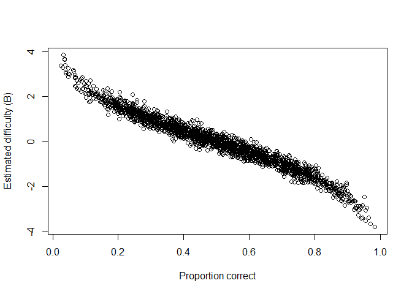

```r
plot(chk_r$p_correct, chk_r$B,
     xlab = "Proportion correct", ylab = "Estimated difficulty (B)")
```

```r
np_r <- normaliseIRT(B = fit1pl_r$itemPars$B,
                     A = fit1pl_r$itemPars$A,
                     Ability = fit1pl_r$pars$Ability)

itempars_r_norm <- data.table(Item = fit1pl_r$itemPars$Item,
                            A = np_r$A, B = np_r$B)

fwrite(itempars_r, "repeat_item_estimates_1pl.csv")
```

## 4. Comparing Item Estimates

A comparison of the item estimates found high correlations *r* ≈ .9 between the “true” estimates, DF_missing, and DF_repeat.

```
## Comparing DF with DF_missing
## Pearson's r:      0.929
## Spearman's rho:   0.931
```

```
## Comparing DF with DF_repeat
## Pearson's r:      0.902
## Spearman's rho:   0.903
```

```
## Comparing DF_missing with DF_repeat
## Pearson's r:      0.971
## Spearman's rho:   0.970
```